# Mboost Tutorial

## Generalized Linear Models - glmboost

Objetivo: prever DEXfat usando outras variáveis mais facilmente computáveis

```r
head(bodyfat)
```

|  | age | DEXfat | waistcirc | hipcirc | elbowbreadth | kneebreadth | anthro3a | anthro3b | anthro3c | anthro4 |
| --- | --- | --- | --- | --- | --- | --- | --- | --- | --- | --- |
| 47 | 57 | 41.68 | 100.0 | 112.0 | 7.1 | 9.4 | 4.42 | 4.95 | 4.50 | 6.13 |
| 48 | 65 | 43.29 | 99.5 | 116.5 | 6.5 | 8.9 | 4.63 | 5.01 | 4.48 | 6.37 |
| 49 | 59 | 35.41 | 96.0 | 108.5 | 6.2 | 8.9 | 4.12 | 4.74 | 4.60 | 5.82 |
| 50 | 58 | 22.79 | 72.0 | 96.5 | 6.1 | 9.2 | 4.03 | 4.48 | 3.91 | 5.66 |
| 51 | 60 | 36.42 | 89.5 | 100.5 | 7.1 | 10.0 | 4.24 | 4.68 | 4.15 | 5.91 |
| 52 | 61 | 24.13 | 83.5 | 97.0 | 6.5 | 8.8 | 3.55 | 4.06 | 3.64 | 5.14 |

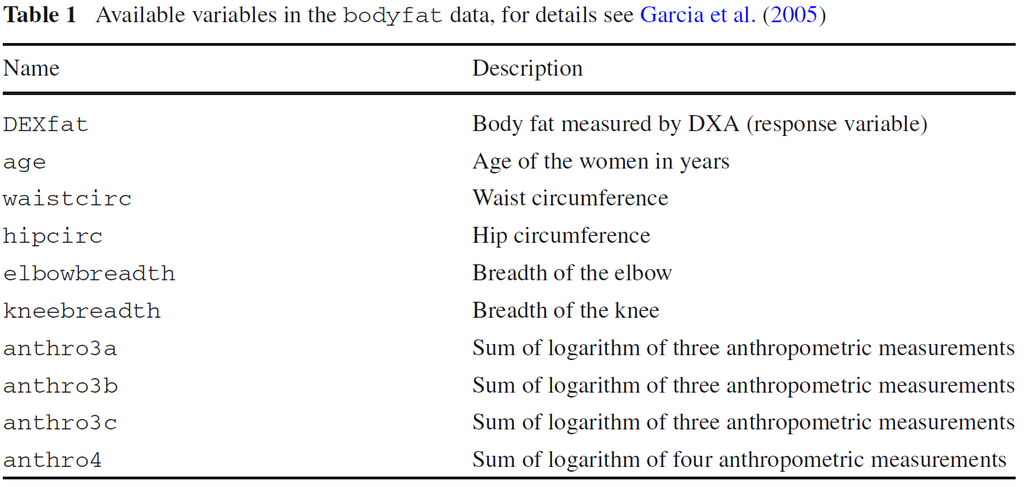

No paper original, foi feita uma regressão linear simples, que pode ser facilmente reproduzida com `glmboost()`. Ainda, usando `family = Gaussian()` e o default para `control`, teremos um boosting com L2 Loss

```r
lm1 <- lm(DEXfat ~ hipcirc + kneebreadth + anthro3a, data = bodyfat)
coef(lm1)
```

```
## (Intercept)     hipcirc kneebreadth    anthro3a
## -75.2347840   0.5115264   1.9019904   8.9096375
```

```r
glm1 <- glmboost(DEXfat ~ hipcirc + kneebreadth + anthro3a, data = bodyfat, family = Gaussian())
coef(glm1, off2int=TRUE)
```

```
## (Intercept)     hipcirc kneebreadth    anthro3a
## -75.2073365   0.5114861   1.9005386   8.9071301
```

Para usar todos regressores basta colocar (.) ao invés dos nomes

Como a função `coef()` por default mostra apenas as variáveis selecionadas, podemos usar `which = ""` para exibir as não selecionadas, nesse caso *anthro4*

```r
glm2 <- glmboost(DEXfat ~ ., data = bodyfat, family = Gaussian())
coef(glm2,which = "")
```

```
##  (Intercept)          age    waistcirc      hipcirc elbowbreadth  kneebreadth
##  -98.8166077    0.0136017    0.1897156    0.3516258   -0.3841399    1.7365888
##     anthro3a     anthro3b     anthro3c      anthro4
##    3.3268603    3.6565240    0.5953626    0.0000000
## attr(,"offset")
## [1] 30.78282
```

É possível visualizar os “coefficients paths” fornecendo o modelo resultante para `plot()`

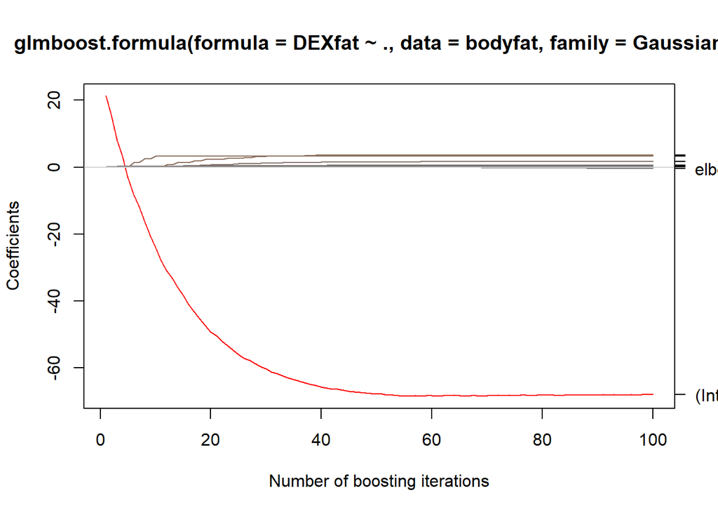

```r
plot(glm2, off2int = T)
```

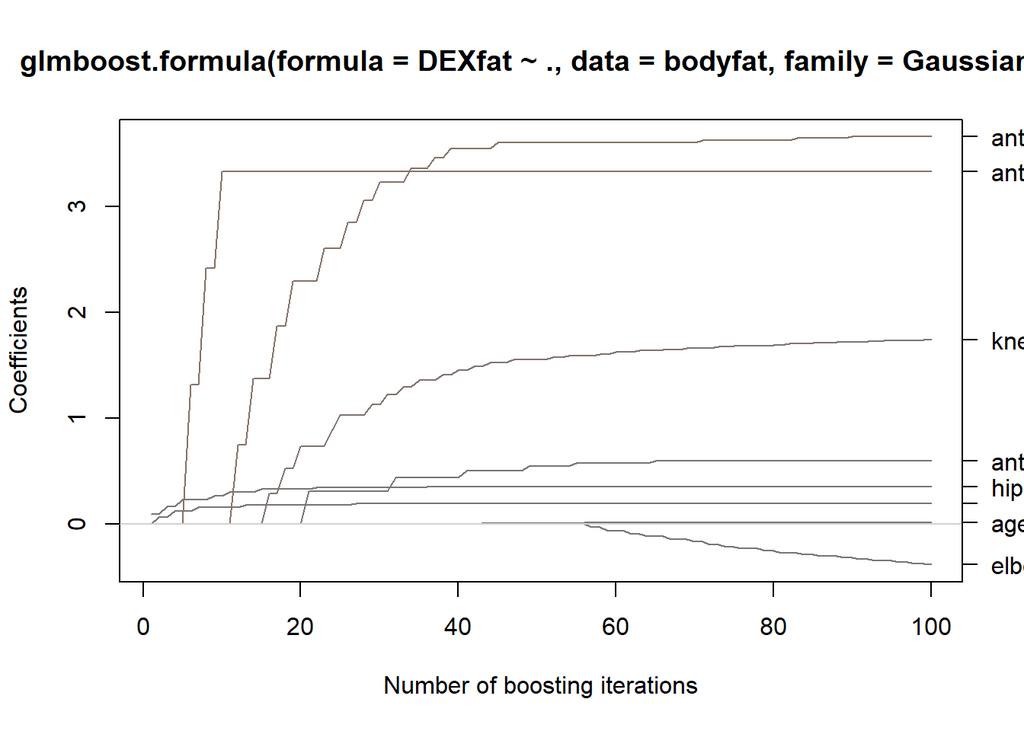

```r
preds <- names(bodyfat)[-2]
plot(glm2, ylim = range(coef(glm2, which = preds))) #Sem o intercepto
```

## Generalized Additive Models - gamboost

Usar os mesmos regressores do modelo original do paper, mas considerando um efeito smooth

```r
gam1 <- gamboost(DEXfat ~ bbs(hipcirc) + bbs(kneebreadth) + bbs(anthro3a), data = bodyfat)
```

Passando um modelo GAM para `plot()`, obtemos um gráfico para o efeito parcial de cada regressor

No exemplo abaixo, parece que os três regressores apresentam relação linear para os valores médios e uma provável relação não-linear nos extremos

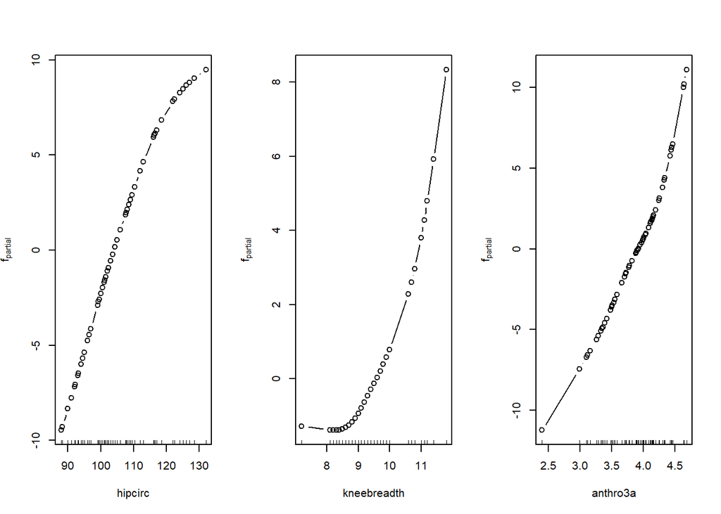

```r
par(mfrow = c(1,3))
plot(gam1)
```

## Early Stopping

Para evitar overfitting é preciso definir um mstop ideal, sendo que podemos usar AIC ou Cross-Validation

### AIC

No artigo dos meninos, a função criada por eles para o boosting, rodava o modelo com `glmboost()` e depois calculava o AIC usando o modelo resultante. Depois, na hora predição selecionavam algo no modelo resultante usando como índice `mstop(AIC)` com o valor de AIC resultante

Usando o exemplo do Dexfat podemos analisar cada um desses passos

Primeiro, rodamos o modelo e usando AIC no modelo resultante obtemos, entre outras coisas, o número ótimo de iterações para o boosting

```r
glm2 <- glmboost(DEXfat ~ ., data = bodyfat, family = Gaussian())

(AIC = AIC(glm2, method = "corrected" , df = "actset"))
```

```
## [1] 3.528995
## Optimal number of boosting iterations: 42
## Degrees of freedom (for mstop = 42): 7
```

Colocando o resultado do AIC dentro de `mstop()` extraimos apenas o número de iterações

```r
mstop(AIC)
```

```
## [1] 42
```

Por fim, usando esse valor como índice no objeto em que o modelo está guardado obtemos o modelo naquela iteração (42)

```r
glm2[mstop(AIC)]
```

```
##
##   Generalized Linear Models Fitted via Gradient Boosting
##
## Call:
## glmboost.formula(formula = DEXfat ~ ., data = bodyfat, family = Gaussian())
##
##
##   Squared Error (Regression)
##
## Loss function: (y - f)^2
##
##
## Number of boosting iterations: mstop = 42
## Step size:  0.1
## Offset:  30.78282
##
## Coefficients:
## (Intercept)   waistcirc     hipcirc kneebreadth    anthro3a    anthro3b
## -97.1727247   0.1893046   0.3488781   1.4890359   3.3268603   3.5468234
##    anthro3c
##   0.5043133
## attr(,"offset")
## [1] 30.78282
```

O que ocorre, é que apesar do mstop fornecido inicialmente, o ato de indexação desse pacote altera diretamente o objeto. Portanto, mesmo que o modelo glm2 foi construído com mstop = 100 (default) ao fazer a indexação acima ele é alterado para mstop = 42

Podemos ainda plotar o objeto AIC para ver a evolução a cada iteração

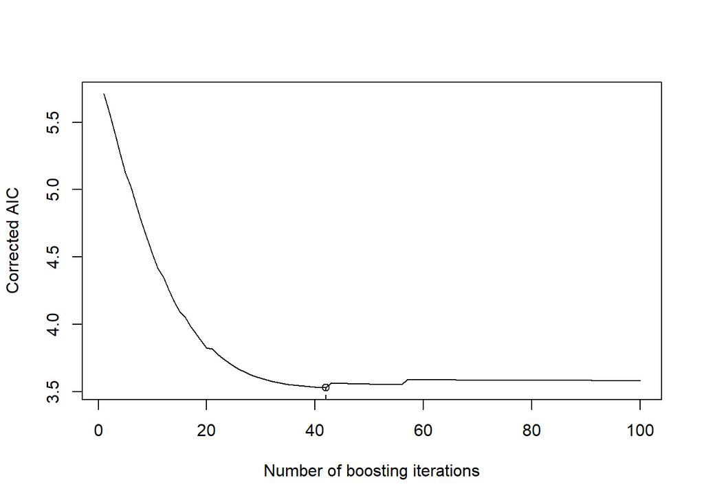

```r
plot(AIC)
```

### Cross-Validation

Segue a mesma lógica, alterando apenas a função para calcular o mstop ideal

Primeiro fazemos o modelo

```r
gam2 <- gamboost(DEXfat ~ ., baselearner = "bbs", data = bodyfat)
```

Depois usamos a função `cvrisk()` para descobrir o número ideal de iterações

```r
cvm <- cvrisk(gam2)
mstop(cvm)
```

```
## [1] 39
```

Por fim, extraímos o valor da iteração ideal com `mstop()` e usamos para indexar o modelo, alterando-o diretamente para sua forma ideal

```r
gam2[mstop(cvm)]
```

```
##
##   Model-based Boosting
##
## Call:
## gamboost(formula = DEXfat ~ ., data = bodyfat, baselearner = "bbs")
##
##
##   Squared Error (Regression)
##
## Loss function: (y - f)^2
##
##
## Number of boosting iterations: mstop = 39
## Step size:  0.1
## Offset:  30.78282
## Number of baselearners:  9
```

Também podemos plotar o resultado em cvm

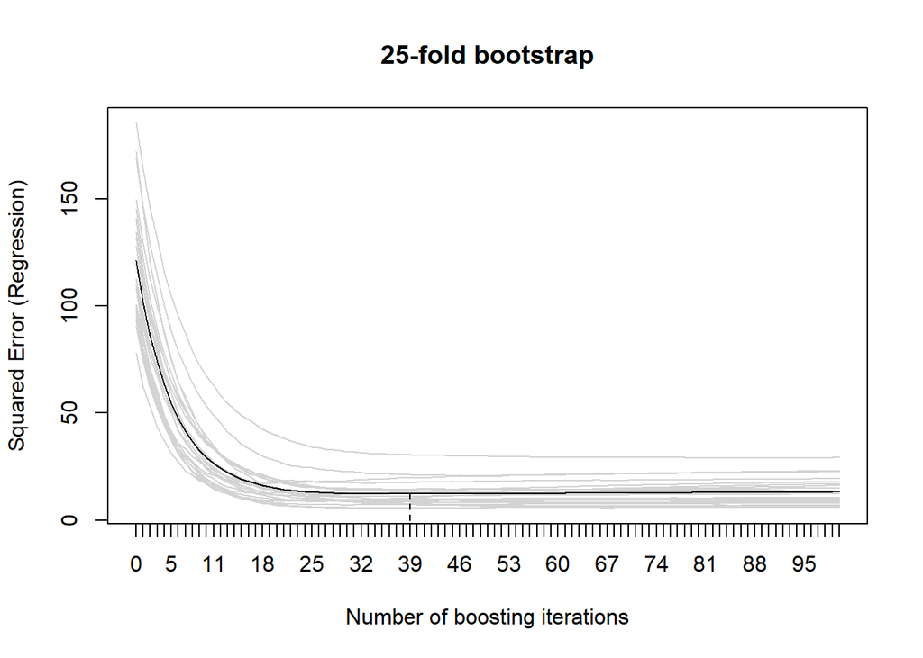

```r
plot(cvm)
```

Por padrão é bootstrap, mas podemos usar k-fold e subsampling no cross-validation

## Families

O argumento `family` das funções `glmboost()` e `gamboost()` define a Loss Function e o gradiente negativo correspondente

Aém das opções implementadas pelo pacote, é possível definir as próprias funções Loss com a função auxiliar `Family()`

**Gaussian**

- média condicional de variável resposta contínua
- Y|x é normalment distribuído e a Loss Function é negativo da Gaussian Log-Likelihood
- L2 Loss

```r
Gaussian()
```

```
##
##   Squared Error (Regression)
##
## Loss function: (y - f)^2
##
```

**LaPlace**

- mediana condicional da distribuição
- útil para distribuições de erro de caudas longas
- L1 Loss

```r
Laplace()
```

```
##
##   Absolute Error
##
## Loss function: abs(y - f)
##
```

**Huber**

- meio termo entre L1 e L2 útil para quando robustez é importante
- Parâmetro delta por default `d = NULL` é adaptativo

```r
Huber()
```

```
##
##   Huber Error (with adaptive d)
##
## Loss function: {
##      if (is.null(d))
##          d <- median(abs(y - fit))
##      ifelse((a <- abs(y - f)) < d, a^2/2, d * (a - d/2))
##  }
##
```

**QuantReg**

- modelar quantis condicionais com quantile regression
- robusta a outliers e não depende de hipóteses sobre a distribuição dos erros ou da variável resposta
- QuantReg(0.5) e LaPlace resultam ambos na regressão da mediana
- requer mstop maior

```r
QuantReg()
```

```
##
##   Quantile Regression
##
## Loss function: tau * (y - f) * ((y - f) >= 0) - (1 - tau) * (y - f) * ((y -
##      f) < 0)
##
```

**Resposta Binária**

- Binomial() ou AdaExp()

```r
Binomial()
```

```
##
##   Negative Binomial Likelihood (logit link)
##
## Loss function: {
##      f <- pmin(abs(f), 36) * sign(f)
##      p <- exp(f)/(exp(f) + exp(-f))
##      y <- (y + 1)/2
##      -y * log(p) - (1 - y) * log(1 - p)
##  }
##
```

```r
AdaExp()
```

```
##
##   Adaboost Exponential Error
##
## Loss function: exp(-y * f)
##
```

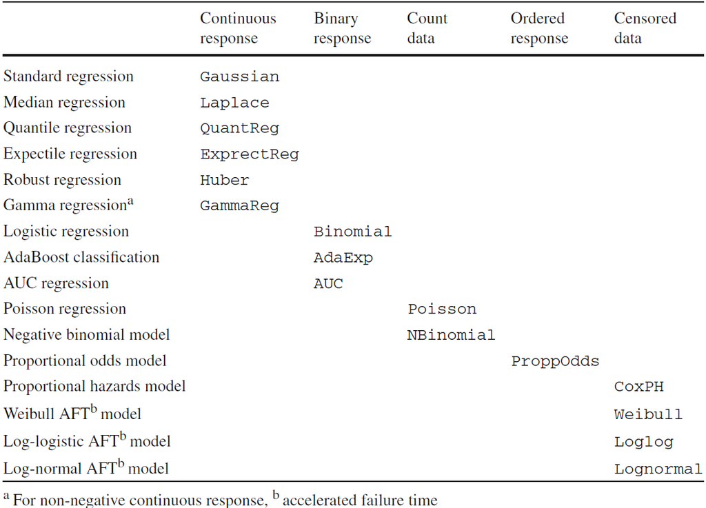